# Assignment3_JianghongMan

Jianghong Man

4/19/2021

0. Set the working directory and load the libary

```r
setwd('~/Desktop/Time_Series/3/')
library(fpp)
```

```r
library(ggplot2)
library(dplyr)
library(lubridate)
library(urca)
library(TSA)
```

For this exercise, we will use the annual World’s bank US GDP (Gross domestic product) 1960 – 2017 dataset (Data set: usgdp.rda).

1. Load the usgdp.rda dataset and split it into a training dataset (1960 - 2012) and a test dataset (2013 - 2017)

```r
# Load the data
load(file = "usgdp.rda")
data  <- ts(usgdp$GDP, start = 1960)
train <- window(data, start = 1960, end = 2012)
test  <- window(data, start = 2013, end = 2017)
```

2. Plot the training dataset. Is the Box-Cox transformation necessary for this data?

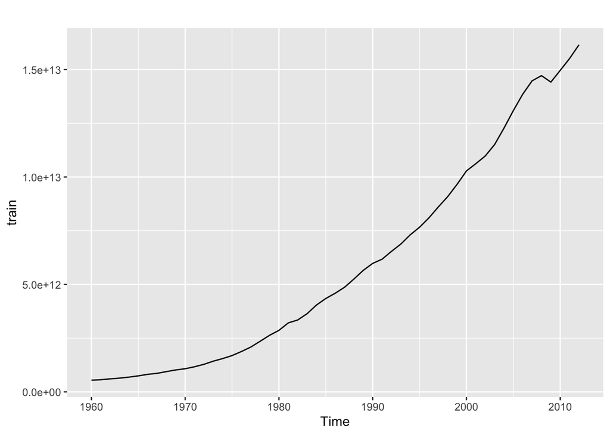

```r
autoplot(train)
```

Yes, it is necessary. The curve is a little bit convave up, and it shows increasing variantion as the level of the series increases. Thus, we need the Box-Cox transformation to stabilize the variance.

```r
# to balance the seasonal fluctuations and random variation across the series.
lambda <- BoxCox.lambda(train)
lambda
```

```
## [1] 0.2310656
```

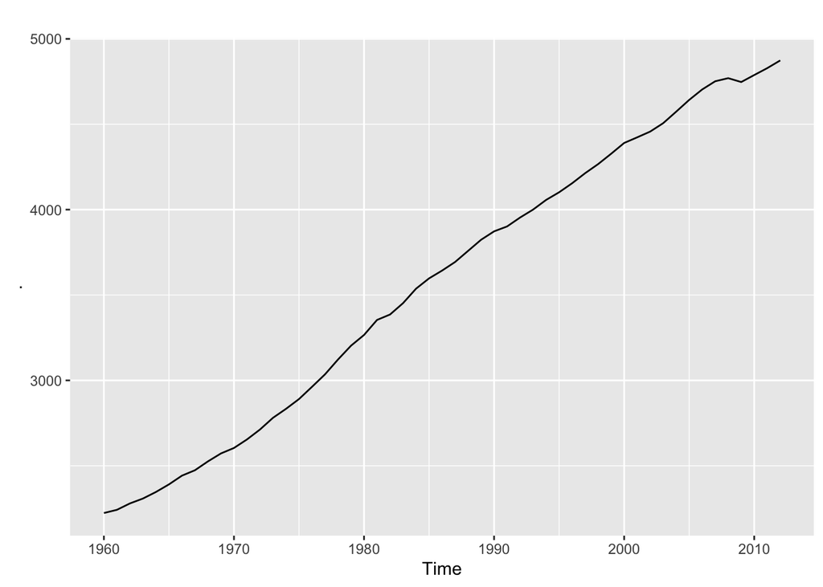

```r
# Re-plot the training data after Box-Cox transformation
train %>% BoxCox(lambda = 0.2310656) %>% autoplot()
```

3. Plot the 1st and 2nd order difference of the data. Apply KPSS Test for Stationarity to determine which difference order results in a stationary dataset.

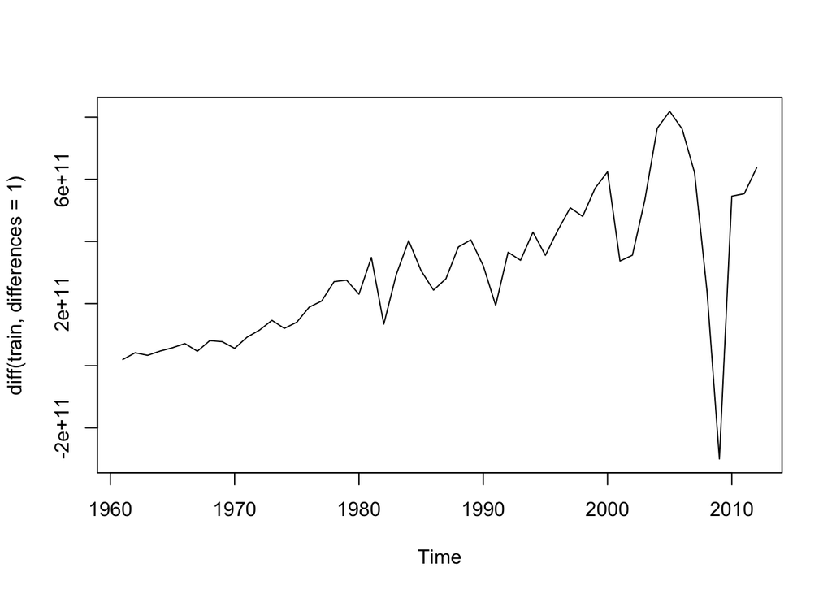

```r
plot(diff(train, differences = 1))
```

```r
kpss.test(diff(train, differences = 1))
```

```
##
##  KPSS Test for Level Stationarity
##
## data:  diff(train, differences = 1)
## KPSS Level = 1.1194, Truncation lag parameter = 3, p-value = 0.01
```

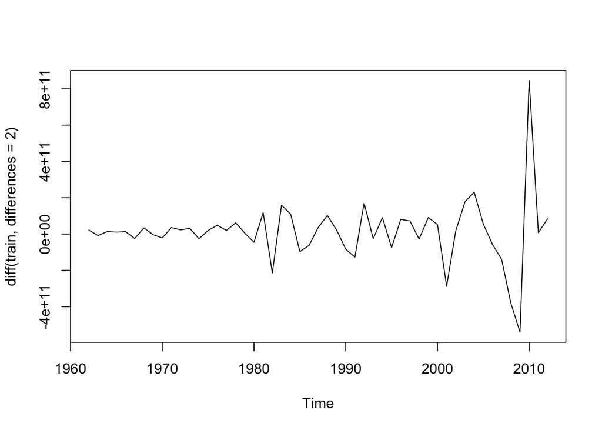

```r
plot(diff(train, differences = 2))
```

```r
kpss.test(diff(train, differences = 2))
```

```
##
##  KPSS Test for Level Stationarity
##
## data:  diff(train, differences = 2)
## KPSS Level = 0.030686, Truncation lag parameter = 3, p-value = 0.1
```

4. Fit a suitable ARIMA model to the training dataset using the auto.arima() function. Remember to transform the data first if necessary. Report the resulting 𝑝,𝑑,𝑞 and the coefficients values.

```r
trans.train <- BoxCox(train, lambda = 0.2310656)

fit <- auto.arima(trans.train)
fit
```

```
## Series: trans.train
## ARIMA(1,1,0) with drift
##
## Coefficients:
##          ar1    drift
##       0.4728  50.3366
## s.e.  0.1242   4.3713
##
## sigma^2 estimated as 295.7:  log likelihood=-220.81
## AIC=447.62   AICc=448.12   BIC=453.47
```

According to the summary(fit) result, Series: train is ARIMA(1,1,0), with drift p = 1, d = 1, q = 0

Coefficients: ar1 drift 0.4728 50.3366

5. Compute the sample Extended ACF (EACF) and use the Arima() function to try some other plausible models by experimenting with the orders chosen. Limit your models to 𝑞,𝑝 ≤2 and 𝑑≤2. Use the model summary() function to compare the Corrected Akaike information criterion (i.e., AICc) values (Note: Smaller values indicated better models).

```r
eacf(trans.train)
```

```
## AR/MA
##   0 1 2 3 4 5 6 7 8 9 10 11 12 13
## 0 x x x x x x x x x x x  x  o  o
## 1 x o o o o x o o o o o  o  o  o
## 2 o o o o o o o o o o o  o  o  o
## 3 x o o o o o o o o o o  o  o  o
## 4 x o o o o o o o o o o  o  o  o
## 5 x o o o o o o o o o o  o  o  o
## 6 x o o x o o o o o o o  o  o  o
## 7 x x o o o o o o o o o  o  o  o
```

```r
fit.train <- trans.train %>% Arima(order = c(1, 1, 0))
summary(fit.train) # AICc=460.99
```

```
## Series: .
## ARIMA(1,1,0)
##
## Coefficients:
##          ar1
##       0.9273
## s.e.  0.0445
##
## sigma^2 estimated as 375.3:  log likelihood=-228.37
## AIC=460.75   AICc=460.99   BIC=464.65
##
## Training set error measures:
##                    ME     RMSE     MAE       MPE      MAPE      MASE       ACF1
## Training set 4.248866 19.00238 14.7389 0.1374233 0.4244543 0.2842964 -0.2721034
```

```r
fit.1 <- trans.train %>% Arima(order = c(1, 1, 1))
summary(fit.1) # AICc=455.03
```

```
## Series: .
## ARIMA(1,1,1)
##
## Coefficients:
##          ar1      ma1
##       0.9890  -0.6489
## s.e.  0.0137   0.1413
##
## sigma^2 estimated as 324.6:  log likelihood=-224.26
## AIC=454.53   AICc=455.03   BIC=460.38
##
## Training set error measures:
##                    ME     RMSE     MAE       MPE      MAPE      MASE      ACF1
## Training set 2.462329 17.49977 13.7269 0.1042901 0.3908161 0.2647761 0.1611916
```

```r
fit.2 <- trans.train %>% Arima(order = c(1, 1, 2))
summary(fit.2) # AICc=454.63
```

```
## Series: .
## ARIMA(1,1,2)
##
## Coefficients:
##          ar1      ma1      ma2
##       0.9927  -0.4893  -0.2200
## s.e.  0.0102   0.1394   0.1326
##
## sigma^2 estimated as 313.7:  log likelihood=-222.89
## AIC=453.78   AICc=454.63   BIC=461.58
##
## Training set error measures:
##                   ME     RMSE      MAE       MPE      MAPE      MASE       ACF1
## Training set 2.32895 17.02903 13.29847 0.1031669 0.3843492 0.2565122 0.01041266
```

```r
fit.3 <- trans.train %>% Arima(order = c(2, 1, 0))
summary(fit.3) # AICc=459.91
```

```
## Series: .
## ARIMA(2,1,0)
##
## Coefficients:
##          ar1     ar2
##       0.6932  0.2494
## s.e.  0.1332  0.1342
##
## sigma^2 estimated as 358.4:  log likelihood=-226.71
## AIC=459.41   AICc=459.91   BIC=465.27
##
## Training set error measures:
##                    ME     RMSE      MAE       MPE      MAPE     MASE       ACF1
## Training set 3.590773 18.38907 14.74131 0.1210549 0.4183488 0.284343 -0.0758984
```

```r
fit.4 <- trans.train %>% Arima(order = c(2, 1, 1))
summary(fit.4) # AICc=454.91
```

```
## Series: .
## ARIMA(2,1,1)
##
## Coefficients:
##          ar1      ar2      ma1
##       1.2899  -0.2946  -0.8039
## s.e.  0.1925   0.1893   0.1232
##
## sigma^2 estimated as 315.4:  log likelihood=-223.03
## AIC=454.06   AICc=454.91   BIC=461.86
##
## Training set error measures:
##                    ME     RMSE      MAE      MPE      MAPE      MASE       ACF1
## Training set 2.331154 17.07529 13.41993 0.103171 0.3875013 0.2588551 0.03061293
```

```r
fit.5 <- trans.train %>% Arima(order = c(2, 1, 2))
summary(fit.5) # AICc=457.09
```

```
## Series: .
## ARIMA(2,1,2)
##
## Coefficients:
##          ar1     ar2      ma1      ma2
##       0.9772  0.0152  -0.4746  -0.2299
## s.e.  0.5770  0.5709   0.5556   0.3667
##
## sigma^2 estimated as 320.4:  log likelihood=-222.89
## AIC=455.78   AICc=457.09   BIC=465.54
##
## Training set error measures:
##                    ME     RMSE      MAE       MPE      MAPE      MASE
## Training set 2.369935 17.03431 13.30734 0.1044133 0.3846292 0.2566833
##                    ACF1
## Training set 0.01102334
```

```r
fit.6 <- trans.train %>% Arima(order = c(1, 2, 0))
summary(fit.6) # AICc=448.43
```

```
## Series: .
## ARIMA(1,2,0)
##
## Coefficients:
##           ar1
##       -0.2752
## s.e.   0.1343
##
## sigma^2 estimated as 361.6:  log likelihood=-222.09
## AIC=448.18   AICc=448.43   BIC=452.05
##
## Training set error measures:
##                     ME     RMSE    MAE        MPE      MAPE      MASE
## Training set 0.5617728 18.46856 14.189 0.03006174 0.3976796 0.2736894
##                     ACF1
## Training set -0.07133616
```

```r
fit.7 <- trans.train %>% Arima(order = c(1, 2, 1))
summary(fit.7) # AICc=442.5
```

```
## Series: .
## ARIMA(1,2,1)
##
## Coefficients:
##          ar1      ma1
##       0.3138  -0.8217
## s.e.  0.1974   0.1271
##
## sigma^2 estimated as 310.8:  log likelihood=-218
## AIC=441.99   AICc=442.5   BIC=447.79
##
## Training set error measures:
##                     ME     RMSE      MAE        MPE      MAPE      MASE
## Training set 0.8934326 16.95165 13.02114 0.05822128 0.3735492 0.2511629
##                    ACF1
## Training set 0.01921424
```

```r
fit.8 <- trans.train %>% Arima(order = c(1, 2, 2))
summary(fit.8) # AICc=444.62
```

```
## Series: .
## ARIMA(1,2,2)
##
## Coefficients:
##          ar1      ma1      ma2
##       0.0780  -0.5676  -0.1805
## s.e.  0.5523   0.5446   0.3656
##
## sigma^2 estimated as 315.8:  log likelihood=-217.87
## AIC=443.75   AICc=444.62   BIC=451.47
##
## Training set error measures:
##                     ME    RMSE      MAE       MPE     MAPE      MASE
## Training set 0.8252178 16.9112 12.94632 0.0562771 0.371461 0.2497197
##                      ACF1
## Training set -0.001191439
```

```r
fit.9 <- trans.train %>% Arima(order = c(2, 2, 0))
summary(fit.9) # AICc=447.65
```

```
## Series: .
## ARIMA(2,2,0)
##
## Coefficients:
##           ar1      ar2
##       -0.3414  -0.2384
## s.e.   0.1359   0.1342
##
## sigma^2 estimated as 346.8:  log likelihood=-220.57
## AIC=447.14   AICc=447.65   BIC=452.93
##
## Training set error measures:
##                     ME     RMSE      MAE       MPE      MAPE     MASE
## Training set 0.6578575 17.90491 13.82954 0.0356984 0.3873569 0.266756
##                     ACF1
## Training set -0.05075884
```

```r
fit.10 <- trans.train %>% Arima(order = c(2, 2, 1))
summary(fit.10) # AICc=444.49
```

```
## Series: .
## ARIMA(2,2,1)
##
## Coefficients:
##          ar1      ar2      ma1
##       0.2793  -0.1044  -0.7652
## s.e.  0.1996   0.1657   0.1560
##
## sigma^2 estimated as 314.9:  log likelihood=-217.81
## AIC=443.62   AICc=444.49   BIC=451.34
##
## Training set error measures:
##                     ME     RMSE      MAE        MPE      MAPE      MASE
## Training set 0.7511279 16.88873 12.91909 0.05422832 0.3705446 0.2491944
##                      ACF1
## Training set -0.009024764
```

```r
fit.11 <- trans.train %>% Arima(order = c(2, 2, 2))
summary(fit.11) # AICc=443.1
```

```
## Series: .
## ARIMA(2,2,2)
##
## Coefficients:
##          ar1      ar2      ma1     ma2
##       1.2129  -0.5424  -1.8215  1.0000
## s.e.  0.1253   0.1343   0.1188  0.1274
##
## sigma^2 estimated as 274.6:  log likelihood=-215.88
## AIC=441.77   AICc=443.1   BIC=451.43
##
## Training set error measures:
##                      ME     RMSE      MAE        MPE      MAPE      MASE
## Training set -0.1359708 15.60445 11.43901 0.02234024 0.3290486 0.2206455
##                     ACF1
## Training set -0.02525658
```

After try some other plausible models, I found the best model is arima(1,2,1) with the smallest AICc=442.5.

6. Use the model chosen in Question 4 to forecast and plot the GDP forecasts with 80 and 95 % confidence levels for 2013 - 2017 (Test Period).

```r
predict <- forecast((fit), h = 5)
predict
```

```
##      Point Forecast    Lo 80    Hi 80    Lo 95    Hi 95
## 2013       4921.671 4899.632 4943.710 4887.965 4955.376
## 2014       4970.850 4931.616 5010.084 4910.846 5030.853
## 2015       5020.639 4966.444 5074.833 4937.756 5103.522
## 2016       5070.717 5003.528 5137.906 4967.960 5173.473
## 2017       5120.931 5042.315 5199.546 5000.699 5241.163
```

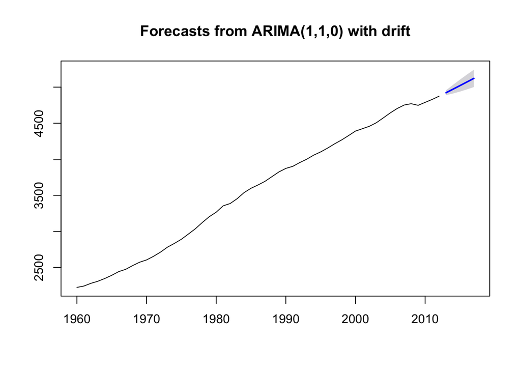

```r
plot(forecast(fit,h=5,level = 0.95))
```

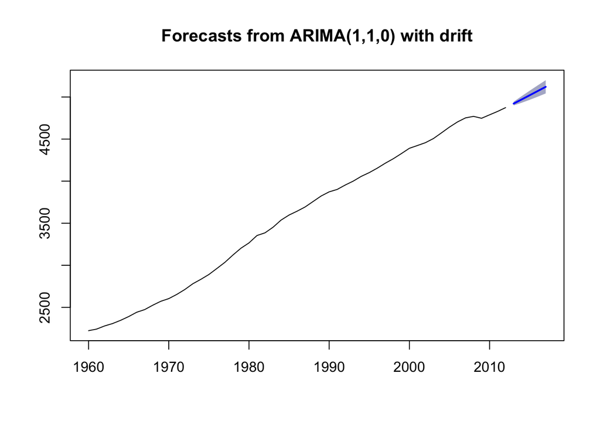

```r
plot(forecast(fit,h=5,level = 0.80))
```

```r
# Express the forecast in the original scale
estimate <- InvBoxCox((predict$mean), lambda = 0.2310656)
estimate
```

```
## Time Series:
## Start = 2013
## End = 2017
## Frequency = 1
## [1] 1.685291e+13 1.759326e+13 1.836801e+13 1.917346e+13 2.000809e+13
```

7. Compare your forecasts with the actual values using error = actual - estimate and plot the errors. (Note: Use the forecast $mean element for the forecast estimate)

```r
error <- test - estimate
error
```

```
## Time Series:
## Start = 2013
## End = 2017
## Frequency = 1
## [1] -161394929125 -165646547626 -247297119039 -548981298743 -617489610161
```

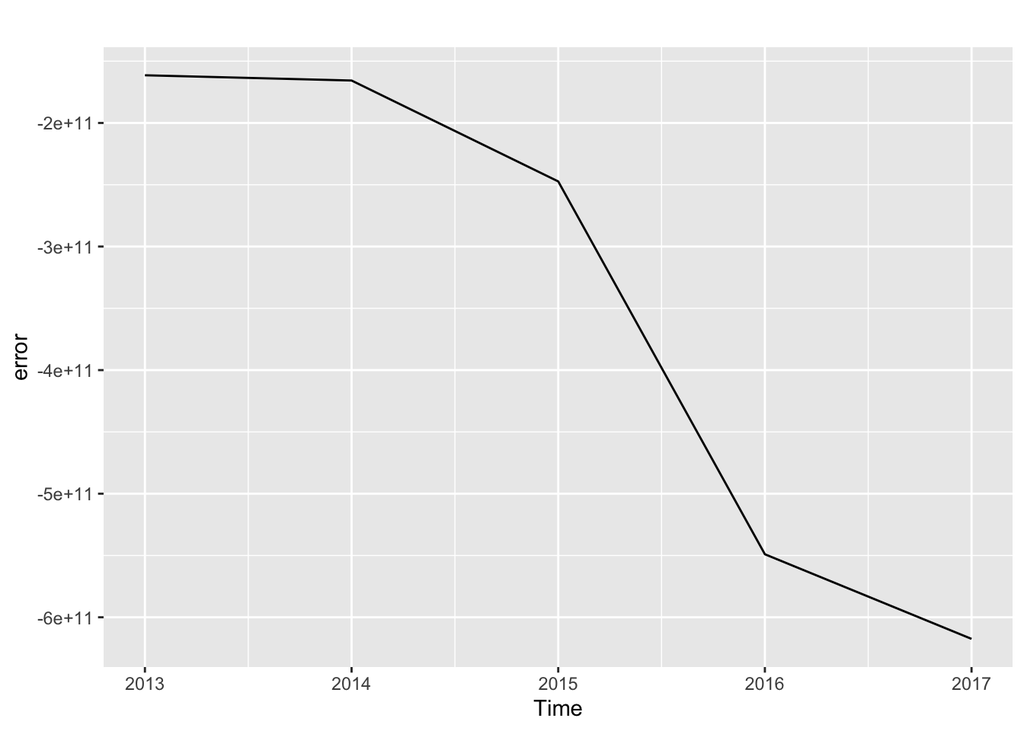

```r
autoplot(error)
```

8. Calculate the sum of squared errors.

```r
SSE <- sum(error^2)
SSE
```

```
## [1] 7.973169e+23
```